### Using the diagram package

You will need to first install the `diagram` package, and then load it in to your workspace,

```r
library(diagram)
```

Consider the following transition matrix,

```r
A <- matrix(c(0, 0, 0, 0,
              0.5, 0, 0, 0,
              0, 0.2, 0, 0,
              0, 0, 0.1, 0), 4, 4, byrow = TRUE)
rownames(A) <- colnames(A) <- c("susceptible", "exposed", "infected", "recovered")
A
```

```
##             susceptible exposed infected recovered
## susceptible         0.0     0.0      0.0         0
## exposed             0.5     0.0      0.0         0
## infected            0.0     0.2      0.0         0
## recovered           0.0     0.0      0.1         0
```

This means that a `susceptible` individual becomes `exposed` at a rate of `0.5`, for example. We can visualize this matrix using the `plotmat` function in the `diagram` package,

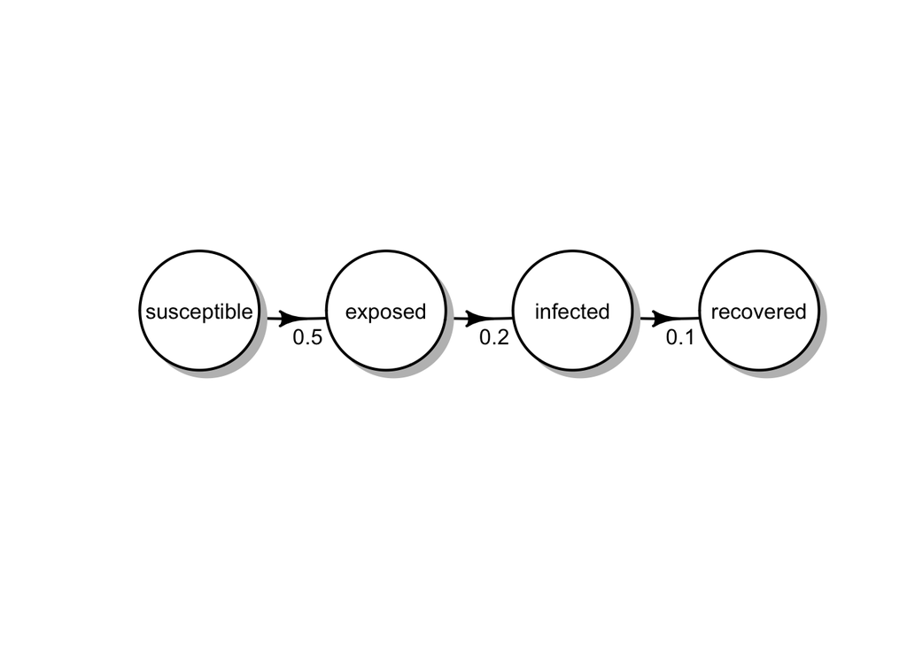

```r
plotmat(A, pos = 4, box.size = 0.08)
```

The `pos = 4` tells `plotmat` that there should be `4` boxes per row.

Now we introduce a `killed` box,

```r
B <- cbind(rbind(A, c(0, 0, 0.01, 0)), rep(0, 5))
rownames(B)[5] <- colnames(B)[5] <- "killed"
B
```

```
##             susceptible exposed infected recovered killed
## susceptible         0.0     0.0     0.00         0      0
## exposed             0.5     0.0     0.00         0      0
## infected            0.0     0.2     0.00         0      0
## recovered           0.0     0.0     0.10         0      0
## killed              0.0     0.0     0.01         0      0
```

It is no longer possible to have every box on the same row, and so things get a bit more complicated. In particular, we need to specify an entire matrix for the `pos` argument. Here is how we go about it,

```r
Bpos <- matrix(c(0.1, 0.3,
                 0.35, 0.3,
                 0.6, 0.3,
                 0.85, 0.3,
                 0.6, 0.8), 5, 2, byrow = TRUE)
rownames(Bpos) <- rownames(B) # naming helps my brain!
colnames(Bpos) <- c("x", "y") # naming helps my brain!
Bpos
```

```
##                x   y
## susceptible 0.10 0.3
## exposed     0.35 0.3
## infected    0.60 0.3
## recovered   0.85 0.3
## killed      0.60 0.8
```

This says that we want to put the `susceptible` box at the x-y coordinates given by `0.10` and `0.3`. We can now plot the diagram,

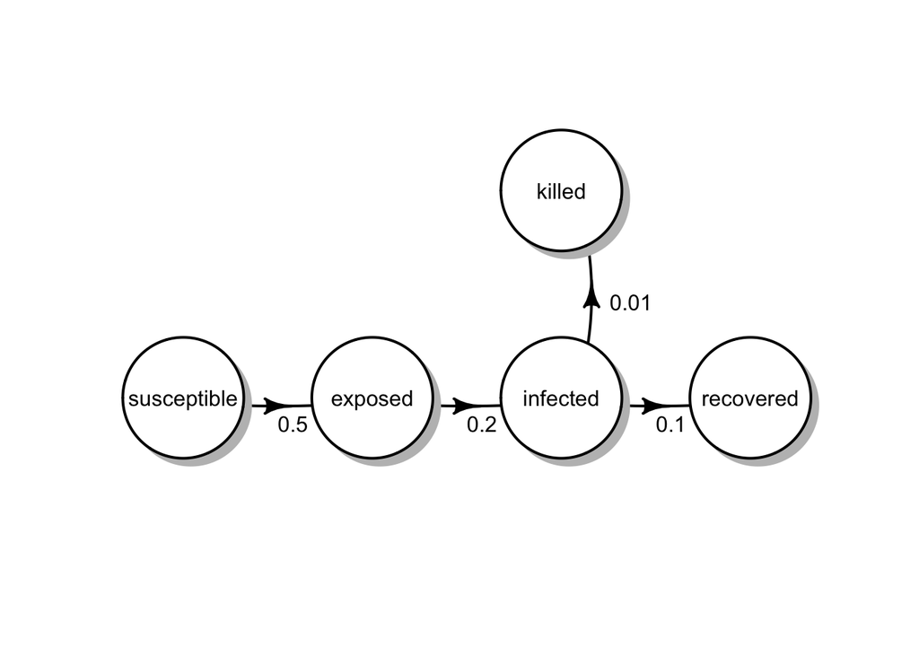

```r
plotmat(B, pos = Bpos, box.size = 0.08)
```

The `diagram` package can do much more http://cran.r-project.org/web/packages/diagram/vignettes/diagram.pdf.

### Use some other drawing program

This way isn’t as much fun! But you could just make a `png` file in another program and load it in to R markdown:

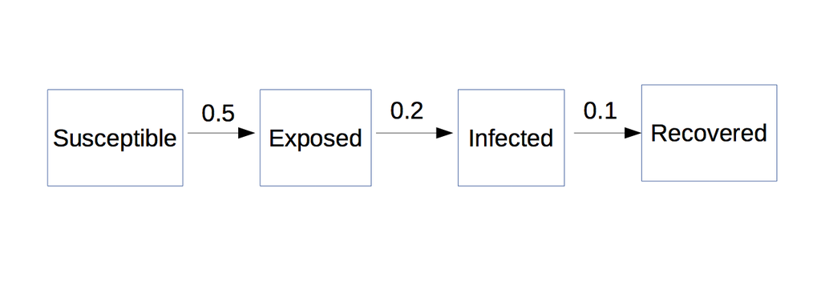